# Initial univariate explorations on synthetic ART-in-HIV data

Hannah Mun

2024-04-21

## Access to data

Synthetic ART-in-HIV data is accessible from https://figshare.com/ndownloader/files/35249488. Below is a brief information about the data loaded.

```
## ──────────────────────────────────────────────────────── Delimiter: "," dbl
## (16): ...1, VL, CD4, Rel CD4, Gender, Ethnic, Base Drug Combo, Comp. INI...
```

```
## Rows: 534,960
## Columns: 16
## $ ...1              <dbl> 0, 1, 2, 3, 4, 5, 6, 7, 8, 9, 10, 11, 12, 13, 14, 15…
## $ VL                <dbl> 1141.895800, 134.190550, 47.274055, 120.055940, 27.2…
## $ CD4               <dbl> 1070.0356, 444.5419, 230.5340, 419.2840, 230.7213, 2…
## $ `Rel CD4`         <dbl> 32.65416, 14.77572, 15.08753, 26.61588, 13.60929, 12…
## $ Gender            <dbl> 1, 1, 1, 1, 1, 1, 1, 1, 1, 1, 1, 1, 1, 1, 1, 1, 1, 1…
## $ Ethnic            <dbl> 4, 4, 4, 4, 4, 4, 4, 4, 4, 4, 4, 4, 4, 4, 4, 4, 4, 4…
## $ `Base Drug Combo` <dbl> 0, 0, 0, 1, 1, 0, 1, 0, 3, 3, 3, 3, 3, 1, 1, 1, 1, 0…
## $ `Comp. INI`       <dbl> 3, 3, 3, 3, 3, 3, 3, 3, 3, 3, 3, 3, 3, 3, 3, 3, 3, 3…
## $ `Comp. NNRTI`     <dbl> 1, 3, 3, 3, 3, 3, 3, 3, 3, 3, 3, 3, 3, 3, 3, 3, 3, 3…
## $ `Extra PI`        <dbl> 5, 5, 5, 5, 5, 5, 5, 3, 3, 5, 1, 5, 1, 3, 3, 5, 5, 5…
## $ `Extra pk-En`     <dbl> 0, 0, 0, 0, 0, 0, 0, 0, 0, 0, 0, 0, 0, 0, 0, 0, 0, 0…
## $ `VL (M)`          <dbl> 1, 1, 0, 1, 1, 0, 1, 0, 0, 0, 1, 0, 1, 0, 0, 1, 0, 1…
## $ `CD4 (M)`         <dbl> 1, 1, 0, 1, 1, 0, 1, 0, 0, 0, 0, 0, 1, 0, 0, 1, 0, 0…
## $ `Drug (M)`        <dbl> 0, 1, 1, 1, 1, 1, 1, 1, 1, 1, 1, 1, 1, 1, 1, 1, 1, 1…
## $ PatientID         <dbl> 0, 0, 0, 0, 0, 0, 0, 0, 0, 0, 0, 0, 0, 0, 0, 0, 0, 0…
## $ Timepoints        <dbl> 0, 1, 2, 3, 4, 5, 6, 7, 8, 9, 10, 11, 12, 13, 14, 15…
```

The dataset includes 16 columns and 534,960 observation (rows). All variable types are numeric with decimal points and some variable names include space in variable names which will require data cleaning process.

## Data cleaning

Firstly, let’s check if there are missing values in the dataset. Below table shows number of missing value in eash column. After checking, there is no missing value found.

```
##            ...1              VL             CD4         Rel CD4          Gender
##               0               0               0               0               0
##          Ethnic Base Drug Combo       Comp. INI     Comp. NNRTI        Extra PI
##               0               0               0               0               0
##     Extra pk-En          VL (M)         CD4 (M)        Drug (M)       PatientID
##               0               0               0               0               0
##      Timepoints
##               0
```

Next, let’s tidy up variable names. We are going to remove space between the variable name and replace with ’_‘, remove’()’ as well as replace the first variable name from ‘…1’ to ‘ID’ as below. We created replicated dataset of ‘df’ and named it ‘df1’ and changes were made to ‘df1’ instead of raw dataset. Variable names after the change are as following.

```
##  [1] "ID"              "VL"              "CD4"             "Rel_CD4"
##  [5] "Gender"          "Ethnic"          "Base_Drug_Combo" "Comp_INI"
##  [9] "Comp_NNRTI"      "Extra_PI"        "Extra_pk_En"     "VL_M"
## [13] "CD4_M"           "Drug_M"          "PatientID"       "Timepoints"
```

Then let’s fix variable types. Currently all of the variables are double integer. According to the information provided, variable types are:

Numeric: VL, CD4  
Binary: Gender, Extra_pk_En, VL_M, CD4_M, Drug_M  
Categorical: Ethnic, Base_Drug_Combo, Comp_INI,Comp_NNRTI,Extra_PI  
Integer: ID, PatientID, Timepoints

Updated variable types are listed below.

```
## tibble [534,960 × 16] (S3: tbl_df/tbl/data.frame)
##  $ ID             : int [1:534960] 0 1 2 3 4 5 6 7 8 9 ...
##  $ VL             : num [1:534960] 1141.9 134.2 47.3 120.1 27.2 ...
##  $ CD4            : num [1:534960] 1070 445 231 419 231 ...
##  $ Rel_CD4        : num [1:534960] 32.7 14.8 15.1 26.6 13.6 ...
##  $ Gender         : Factor w/ 2 levels "1","2": 1 1 1 1 1 1 1 1 1 1 ...
##  $ Ethnic         : Factor w/ 3 levels "2","3","4": 3 3 3 3 3 3 3 3 3 3 ...
##  $ Base_Drug_Combo: Factor w/ 6 levels "0","1","2","3",..: 1 1 1 2 2 1 2 1 4 4 ...
##  $ Comp_INI       : Factor w/ 4 levels "0","1","2","3": 4 4 4 4 4 4 4 4 4 4 ...
##  $ Comp_NNRTI     : Factor w/ 4 levels "0","1","2","3": 2 4 4 4 4 4 4 4 4 4 ...
##  $ Extra_PI       : Factor w/ 6 levels "0","1","2","3",..: 6 6 6 6 6 6 6 4 4 6 ...
##  $ Extra_pk_En    : logi [1:534960] FALSE FALSE FALSE FALSE FALSE FALSE ...
##  $ VL_M           : logi [1:534960] TRUE TRUE FALSE TRUE TRUE FALSE ...
##  $ CD4_M          : logi [1:534960] TRUE TRUE FALSE TRUE TRUE FALSE ...
##  $ Drug_M         : logi [1:534960] FALSE TRUE TRUE TRUE TRUE TRUE ...
##  $ PatientID      : int [1:534960] 0 0 0 0 0 0 0 0 0 0 ...
##  $ Timepoints     : int [1:534960] 0 1 2 3 4 5 6 7 8 9 ...
```

ID, PatientID and Timepoints variables are integer type, Gender, Ethnic, Base_Drug_Combo,Comp_INI,Comp_NNRTI,Extra_PI are factor type and Extra_pk_En, VL_M, CD4_M, Drug_M are logical type. Notice that Ethnic variable has 3 levels of “2”,“3”,“4” without factor “1”. According to background information “1” is Asian, however there is no data its value is “1”. As there was no missing value therefore we assume that there is was no patient whose ethnicity is Asian for now. However in real case, data might be missing and it will need further check before continuing the analysis.

## Data dictionary

Data dictionary is created with label added, and set ID variable as unique identifier variable.

| item | label | class | summary | value |
| --- | --- | --- | --- | --- |
|  |  |  | Rows in dataset | 534960 |
|  |  |  | Columns in dataset | 16 |
| ID | Unique identifier |  | unique values | 534960 |
|  |  |  | missing | 0 |
| VL | Viral Load (copies/mL) | numeric | mean | 906 |
|  |  |  | median | 55 |
|  |  |  | min | 0.91 |
|  |  |  | max | 88600.98 |
|  |  |  | missing | 0 |
| CD4 | Absolute count for CD4 (cells/μL) | numeric | mean | 674 |
|  |  |  | median | 466 |
|  |  |  | min | 39.06 |
|  |  |  | max | 19146.17 |
|  |  |  | missing | 0 |
| Rel_CD4 | Relative count for CD4 (cells/μL) | numeric | mean | 29 |
|  |  |  | median | 26 |
|  |  |  | min | 2.62 |
|  |  |  | max | 356.27 |
|  |  |  | missing | 0 |
| Gender | Gender. 1 = Male, 2 = Female | factor | 1 (1) | 532380 |
|  |  |  | 2 (2) | 2580 |
|  |  |  | missing | 0 |
| Ethnic | Ethnicity. 1 = Asian, 2 = African, 3 = Caucasian, 4 = Other | factor | 2 (1) | 540 |
|  |  |  | 3 (2) | 156360 |
|  |  |  | 4 (3) | 378060 |
|  |  |  | missing | 0 |
| Base_Drug_Combo | Base drug combination. 0 = FTC + TDF, 1 = 3TC + ABC, 2 = FTC + TAF, 3 = DRV + FTC + TDF, 4 = FTC + RTVB + TDF, 5 = Other | factor | 0 (1) | 394078 |
|  |  |  | 1 (2) | 75339 |
|  |  |  | 2 (3) | 5233 |
|  |  |  | 3 (4) | 29436 |
|  |  |  | 4 (5) | 12314 |
|  |  |  | 5 (6) | 18560 |
|  |  |  | missing | 0 |
| Comp_INI | Complementary INI. 0 = DTG, 1 = RAL, 2 = EVG, 3 = Not Applied | factor | 0 (1) | 63975 |
|  |  |  | 1 (2) | 2612 |
|  |  |  | 2 (3) | 25086 |
|  |  |  | 3 (4) | 443287 |
|  |  |  | missing | 0 |
| Comp_NNRTI | Complementary NNRTI. 0 = NVP, 1 = EFV, 2 = RPV, 3 = Not Applied | factor | 0 (1) | 1035 |
|  |  |  | 1 (2) | 49586 |
|  |  |  | 2 (3) | 234088 |
|  |  |  | 3 (4) | 250251 |
|  |  |  | missing | 0 |
| Extra_PI | Extra PI. 0 = DRV, 1 = RTVB, 2 = LPV, 3 = RTV, 4 = ATV, 5 = Not Applied | factor | 0 (1) | 3717 |
|  |  |  | 1 (2) | 21532 |
|  |  |  | 2 (3) | 5787 |
|  |  |  | 3 (4) | 10825 |
|  |  |  | 4 (5) | 22768 |
|  |  |  | 5 (6) | 470331 |
|  |  |  | missing | 0 |
| Extra_pk_En | Extra pk enhancer. 0 = False, 1 = True | logical | FALSE | 517310 |
|  |  |  | TRUE | 17650 |
|  |  |  | missing | 0 |
| VL_M | VL measured. 0 = False, 1 = True | logical | FALSE | 424484 |
|  |  |  | TRUE | 110476 |
|  |  |  | missing | 0 |
| CD4_M | CD4 measured. 0 = False, 1 = True | logical | FALSE | 446090 |
|  |  |  | TRUE | 88870 |
|  |  |  | missing | 0 |
| Drug_M | Drug recorded. 0 = False, 1 = True | logical | FALSE | 83264 |
|  |  |  | TRUE | 451696 |
|  |  |  | missing | 0 |
| PatientID | Synthetic patient ID | integer | mean | 4458 |
|  |  |  | median | 4458 |
|  |  |  | min | 0 |
|  |  |  | max | 8915 |
|  |  |  | missing | 0 |
| Timepoints | Time steps in the time series | integer | mean | 30 |
|  |  |  | median | 30 |
|  |  |  | min | 0 |
|  |  |  | max | 59 |
|  |  |  | missing | 0 |

## EDA on univariate variables

### Patient demographics

Over 99% are male whereas only less than 1% are female data collected. Majority of patients are other ethnicity that are not Asian, African nor Caucasian following Caucasian and African. There is no Asian patient data collected.

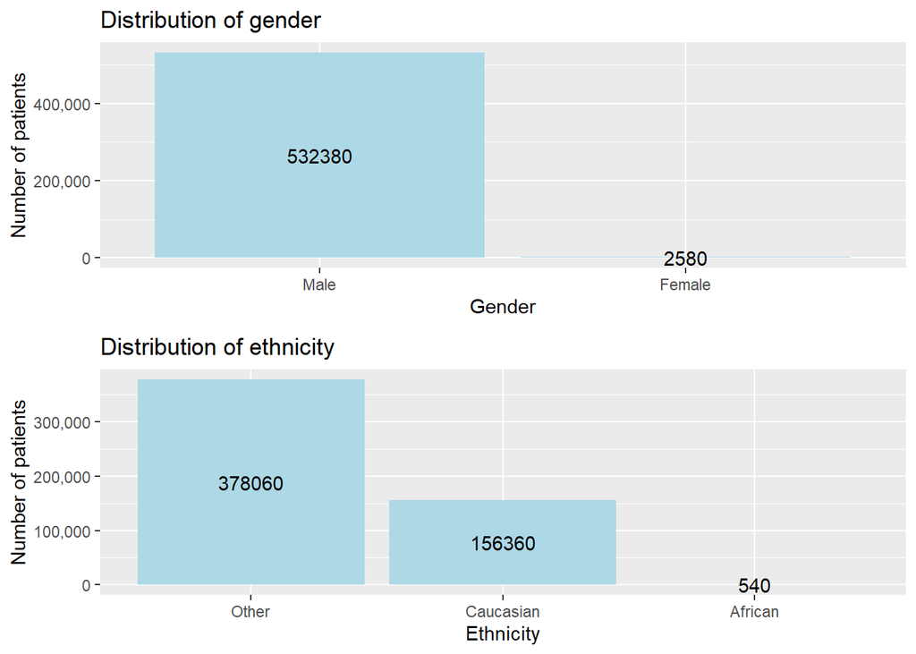

### Health status data measurement

Viral load(VL), absolute count for CV4(CD4) and Relative count for CD4(Rel_CD4) are collected as indicative of the patient’s health status. Each graph shows range of VL, CD4 and Rel_CD4 counted and its average in dashed line.

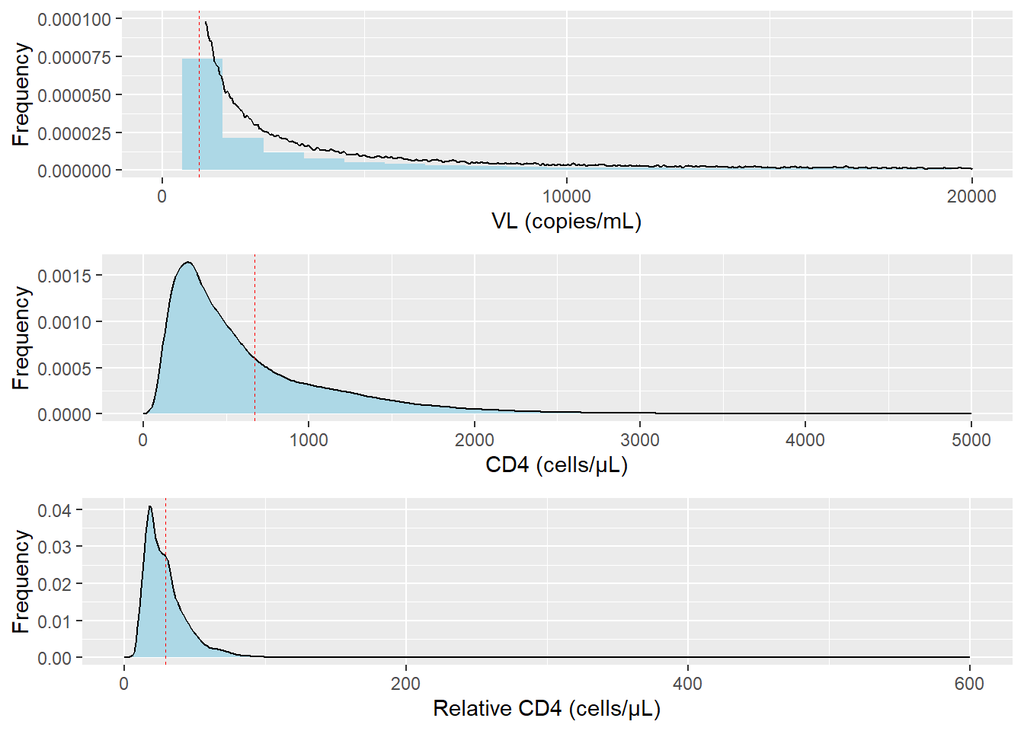

### HIV treatment factors

Distribution of base drug combination(Base_Drug_Combo),complementary INI(Comp_INI), complementary NNRTI(Comp_NNRTI) and extra PI(Extra_PI) are described as below.

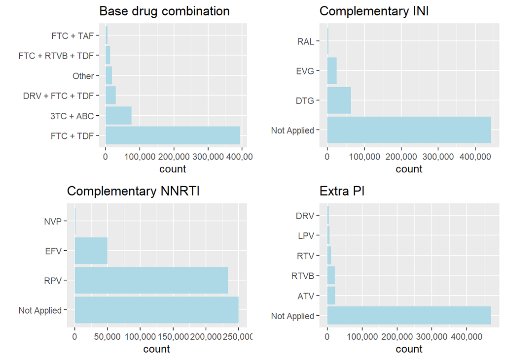

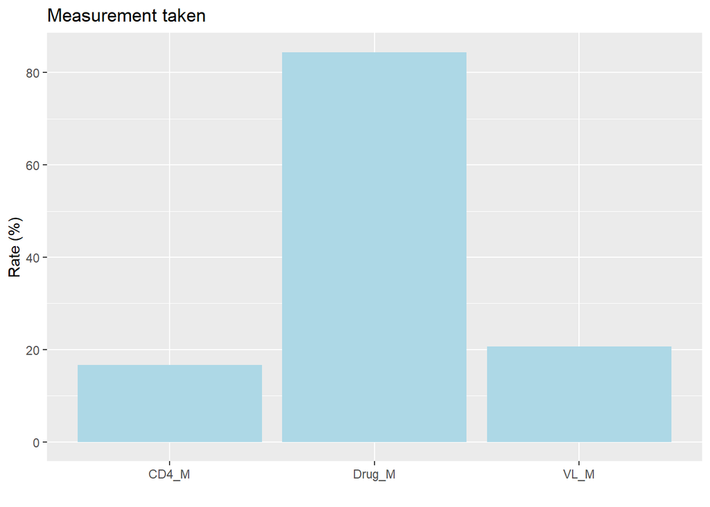

—End of document—